# Problema 1

Rodrigo Farias

July 11, 2016

```r
library(ggplot2, warn.conflicts = FALSE)
library(dplyr, warn.conflicts = FALSE)
ano.atual <- read.csv("~/Documents/workspace/AD1/problema1/dados/ano-atual.csv")
```

## Introdução

No problema 1 da disciplina Análise de Dados 1 pede para ser feita uma análise sobre os dados coletados do site de transparência da câmara dos deputados. Esses dados contém todos os gastos de nossos deputados em 2016 usando a sua cota para exercício da atividade parlamentar.

## Questão 1

1. **Questão** Escolha um subconjunto das variáveis que você considera interessante para investigar como nossos deputados gastam sua verba e comente qual a distribuição dos dados dessas variáveis, em termos de centralidade, extremos, concentração e simetria.

O conjunto escolhido são os gastos dos deputados paraibanos, o gráfico a seguir mostra o boxplot sobre todos os gastos de cada deputado. Onde a média de gastos está destacado em vermelho.

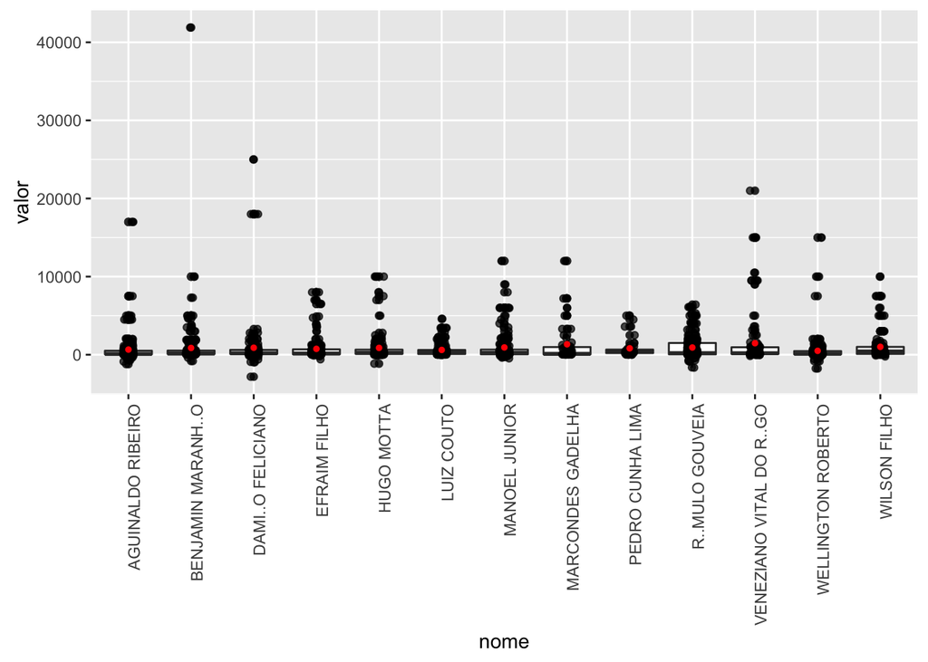

```r
panorama = ano.atual%>%select(1,5, 6, 15, 23)  %>% filter(sgUF =="PB")
names(panorama) = c("partido", "nome", "estado", "descricao", "valor")

panorama.sumarizado = panorama%>% group_by(nome)
panorama.sumarizado.sum = panorama.sumarizado %>%
  summarize(media= mean(valor))
ggplot(panorama.sumarizado, mapping= aes(x = nome,
                                         y = valor))+
  theme(axis.text.x = element_text(angle = 90, hjust = 1))+
  geom_boxplot()+
  geom_point(position = position_jitter(width = .2),
             alpha = .7) +
  geom_point(panorama.sumarizado.sum,
             colour = "red", size = 1,
             mapping = aes(y = media, x = nome))
```

É possível observar que os gastos dos parlamentares tem seus gastos centrais(dentro do box_plot) entre 0 e 1000 reais, os gastos são assimétricos pois é possível notar uma grande concentração na parte de baixo, e poucos pontos soltos acima de 5000. Nota-se também que a média é muito influenciada pelos valores extremos pois em geral ela é maior que 75% das observações.

2. **Questão** Há algo surpreendente ou estranho nos dados?  
   Uma coisa estranha notada nos dados é a presença de valores negativos e alguns valores bem altos que se destacam em comparação com a maioria dos gastos. Ex. gastos acima de 15000.
3. **Questão** como você sugere que um analista de dados lide com a parte surpreendente/estranha?  
   Eu sugiro que o analista investigue sobre os dados negativos e os muito altos para tentar achar um motivo para esses valores estranhos. Um valor muito alto pode ser por que o deputado prefere fazer menos declarações e pegar valores altos para isso. Já os valores negativos em sua maioria são emissão de passagens aéreas, o motivo para isso precisa de um estudo mais detalhado.

## Questão 2.a

#### Em que tipo de despesas nossos parlamentares gastam mais recursos de sua cota?

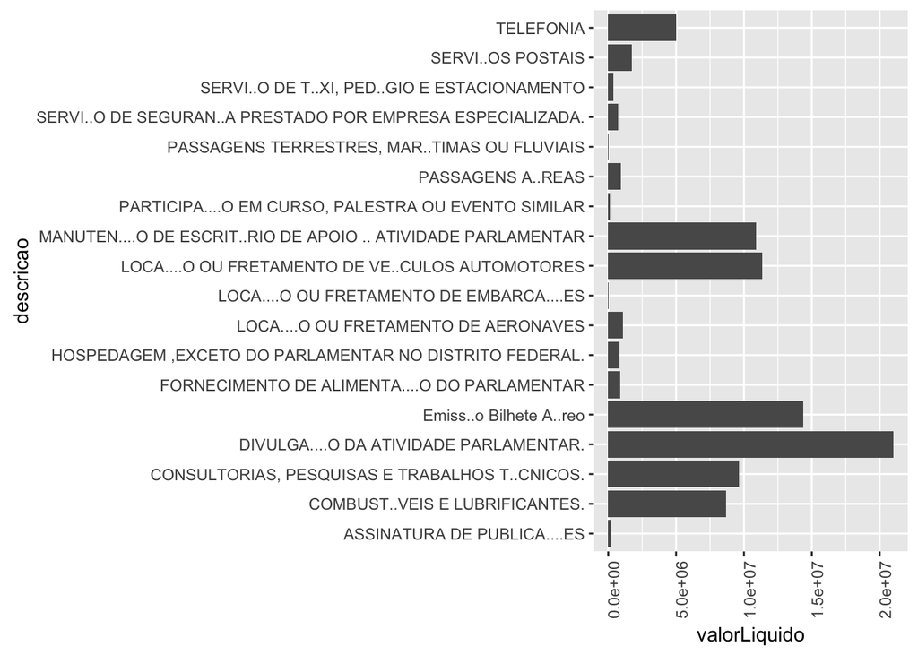

```r
##Selecionando apenas as variavéis descricao dos gastos e valor-liquido
gastos = ano.atual%>%select(15, 23)
names(gastos) = c("descricao", "valor-liquido")

## sumarizando os gastos por grupos e guardando sua soma.
gastos.sumarizados = group_by(gastos, descricao)
gastos.sumarizados.sum = gastos.sumarizados  %>%
  summarise(valorLiquido=sum(`valor-liquido`))

ggplot(gastos.sumarizados.sum, aes(descricao, valorLiquido)) +
  theme(axis.text.x = element_text(angle = 90, hjust = 1))+
  geom_bar(stat="identity", position = "dodge") + coord_flip()
```

Como pode ser observado, os maiores gastos dos nossos parlamentares são com “Divulgação de Atividade Parlamentar”, “Emissão de Bilhete Aéreo” e “Locação de Veículos Automotores”

## Questão 2.b

#### Quais tipos de despesas têm despesas que mais variam, que têm valores mais desiguais?

Aqui vamos utilizar uma métrica chamada desvio padrão para tentarmos visualizar melhor como os valores variam. Desvio Padrão é a medida que informa a média de variação dos valores em torno da média.

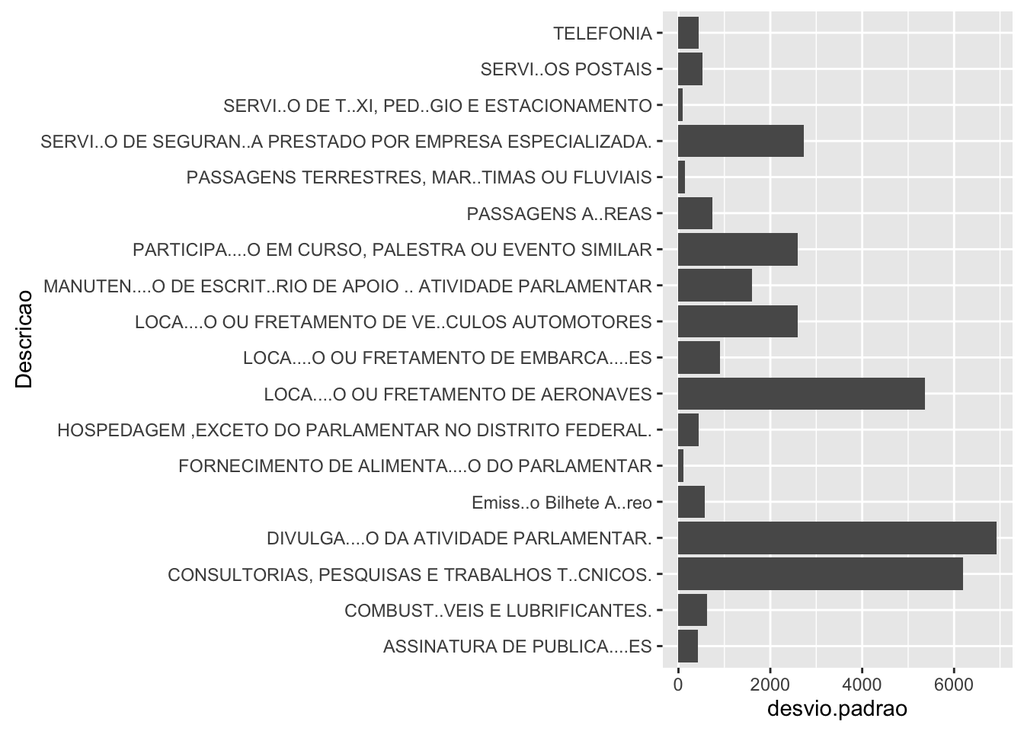

```r
gastos.sumarizados.sd = aggregate(gastos.sumarizados$`valor-liquido`,
                                  list(gastos$descricao), sd)
names(gastos.sumarizados.sd) = c("Descricao", "desvio.padrao")

ggplot(gastos.sumarizados.sd, aes(Descricao, desvio.padrao))+
  geom_bar(stat="identity", position = "dodge") + coord_flip()
```

As 3 categorias que mais variam são “Divulgação de Atividade Parlamentar”, “Cunsultorias, pesquisas e trabalhos técnicos” e “Locação ou Fretamento de Aeronaves”